# Part II - ("Customers vs Subscribers")

## by (David Babayo)

## Investigation Overview

> The main of Goal of this presentation is to convince the viewers on why the customer user type should be discontinued from the bike sharing system

## Dataset Overview

> This data set includes information about individual rides made in a bike-sharing system covering the greater San Francisco Bay area, it contains data for over 183400 bike rides containing information from bike ride duration to type of customer, gender etc for February 2019.

## Number of Customers to Subscribers

The Ford GoBike company has mainly two types of user types which we all know ,which are the Customers and Subscribers but according to recent times the number of Subscribers has grown considerably Larger than the number of customers with almost a 9:1 ratio.

### Distribution of User Type

There are more subscribers than customers as Subscribers take over 90% of the total dataset while customer takes only 9.5% of the pie chart as shown below

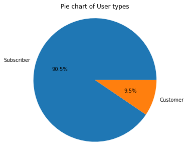

### Countplot showing number of trips of different user types

The countplot below shows the same information as the pie chart above showing the wide gap between number of subsribers and customers with subscribers count reaching about 160,000 users and customers about 20,000 users

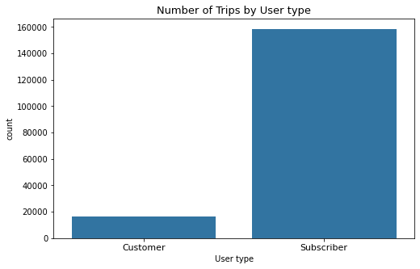

## User types amongst Gender and Part of day

> It does not matter the gender or the part of the day in which rides are made there are always way more subscribers than customers

## Number of trips for various user types among gender types

from the bar chart below across both genders we have more subscribers than customers as in the male category we have almost 120,000 subscribers and less than 20,000 customers where as in females we have almost 40,000 subscribers and less than 20,000 customers

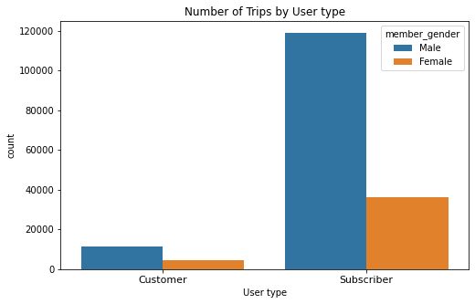

## Distribution of Number of rides for each part of day using user types

we have in every category large gaps between number of subscribers and customers in every part of day as shown in the bar chart below

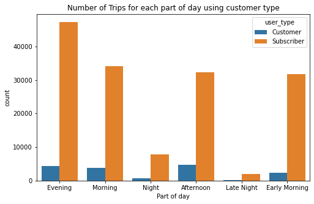

## Trip Duration for various user types

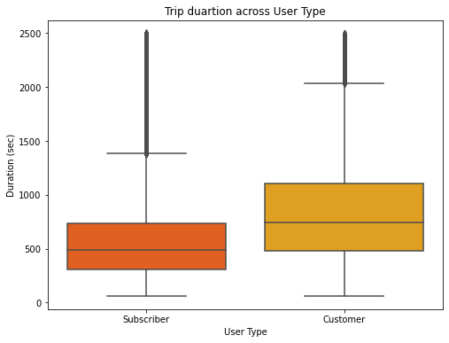